# Celsius Holdings (CELH) 기업 분석 보고서

Alpha Hunter Hidden Gem Week 20 — 에너지음료 3위, PEG 0.31 극저평가 + 52주 최저점

Author

Alpha Hunter × Chimera AI

Published

May 14, 2026

# 기업 개요

| 항목 | 내용 |
| --- | --- |
| **종목명** | Celsius Holdings, Inc. (CELH, NASDAQ) |
| **업종** | Consumer Defensive / 기능성 에너지음료 |
| **핵심 사업** | CELSIUS + Alani Nu + Rockstar 에너지음료 포트폴리오 (PepsiCo 배급) |
| **시총** | $7.1B (약 10.4조원) |
| **현재가** | $27.86 (52주 최저점) |
| **PER (TTM/Fwd)** | 64.8x / 13.7x |
| **PEG** | 0.31x |
| **PSR** | 2.4x |
| **EV/EBITDA** | 13.3x |

> **핵심 투자 포인트**: 미국 에너지음료 시장점유율 20.9%(3위), Q1 매출 +138% YoY, PEG 0.31은 동종업계 최저. 52주 고점 대비 -58% 급락으로 역대급 진입 기회.

# 1 왜 지금 CELH인가?

## 1.1 Alani Nu 인수 효과 — 카테고리 킬러로 진화

2024년 Alani Nu 인수 이후 완벽한 통합에 성공했다. Q1 2026 Alani Nu 매출 $368M(+100% YoY)으로, CELSIUS 본체 매출과 거의 동일한 규모로 성장했다. 핵심은 **PepsiCo 배급 시스템에 Alani Nu를 100% 전환 완료**한 것이다.

- **CELSIUS**: 건강 지향 에너지음료 (MetaPlus 포뮬러, 무설탕)
- **Alani Nu**: 여성 타겟 뉴트리션 + 에너지 (100% 성장)
- **Rockstar Energy**: PepsiCo에서 이관받은 레거시 브랜드 ($66.6M)

세 브랜드가 결합하여 미국 에너지음료 시장의 **20.9% 점유율**을 확보했으며, 이는 Red Bull(35%)과 Monster(28%)에 이은 확고한 3위다.

## 1.2 PepsiCo 배급 — 인프라 독점의 핵심

PepsiCo는 CELH 매출의 **59%**를 담당하는 핵심 유통 파트너다. 이것이 AROC의 “인프라 독점” 패턴과 연결되는 지점이다:

- **AROC**: 천연가스 압축 인프라 독점 → 고객 락인
- **CELH**: PepsiCo 배급 인프라 독점적 활용 → 소매 접근성 극대화

PepsiCo의 100만+ 소매점 배급망을 통해, 신규 브랜드(Alani Nu 등)를 빠르게 전국 확산시킬 수 있다. 이것은 Monster가 Coca-Cola와 맺은 파트너십의 성공 모델을 그대로 따르는 것이다.

## 1.3 해외 확장 — 자본 효율적 성장

국제 사업은 자본경량(capital-light) 모델로 전개 중이다:

- **유럽**: Suntory와 파트너십 (스페인, 포르투갈 진출)
- **글로벌 HQ**: 더블린으로 이전하여 세금 효율화
- 현재 해외 매출 비중은 낮으나, Monster의 해외 비중 40% 대비 **성장 여력이 크다**

# 2 실적 분석

## 2.1 Q1 2026 — 트리플 디짓 성장

| 지표 | Q1 2026 | Q1 2025 | YoY |
| --- | --- | --- | --- |
| **매출** | $783M | $329M | **+138%** |
| **매출총이익** | $378M | $172M | +119% |
| **영업이익** | $143M | $52M | +176% |
| **순이익** | $110M | $44M | +148% |
| **EPS (Adj)** | $0.41 | $0.18 | +128% |

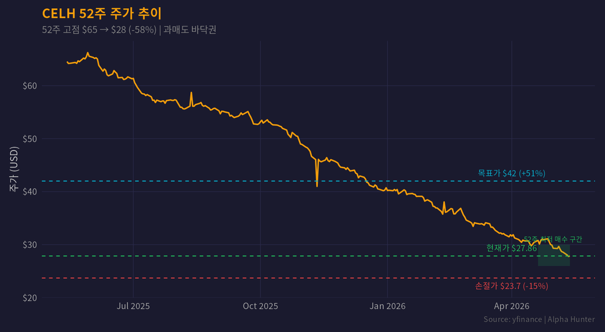

Figure 1: CELH 52주 주가 추이 — 52주 최저점에서 반등 대기

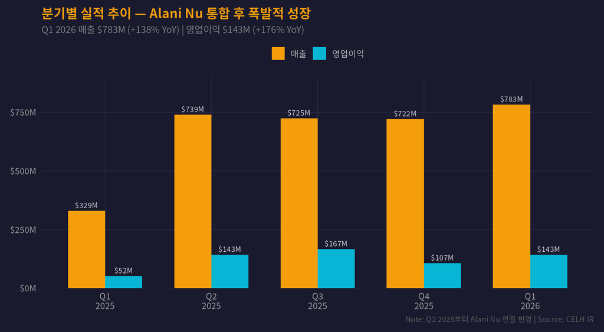

Figure 2: 분기별 매출 및 영업이익 추이 — 트리플 디짓 성장 궤도

## 2.2 매출 구성 — 삼두마차 전략

Q1 2026 매출 $783M의 구성:

- **CELSIUS 브랜드**: ~$348M (전체 44%) — YoY +6% 안정 성장
- **Alani Nu**: $368M (전체 47%) — YoY +100% 폭증
- **Rockstar Energy**: $67M (전체 9%) — PepsiCo에서 이관

미국 에너지음료 카테고리가 Q1에 $800M 성장했는데, CELH가 그 중 **45%를 차지**했다. 카테고리 캡틴(category captain)으로서의 입지가 확고하다.

## 2.3 마진 구조 — 개선 중이나 아직 경쟁사 대비 낮음

| 항목 | CELH | Monster | KDP | Coca-Cola |
| --- | --- | --- | --- | --- |
| **매출총이익률** | 50.4% | 53.1% | 55.8% | 62.5% |
| **영업이익률** | 19.8% | 31.0% | 19.0% | 35.1% |
| **순이익률** | 5.9% | 25.6% | 12.8% | 22.4% |

CELH의 영업이익률 19.8%는 Monster(31%)에 비해 낮으나, Alani Nu 통합 시너지($50M 절감 달성)와 스케일 효과로 **2027년까지 25%+ 목표**가 현실적이다.

# 3 밸류에이션 비교

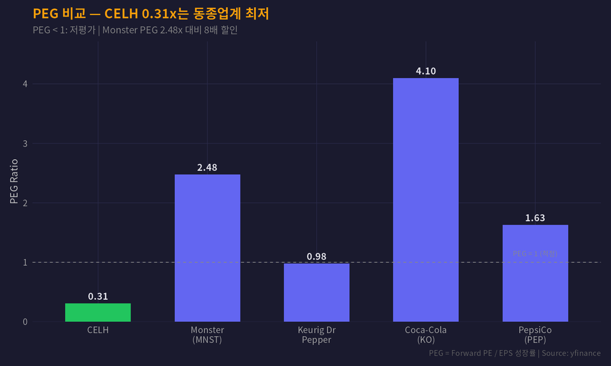

Figure 3: 동종업종 밸류에이션 비교 — CELH PEG 0.31은 역대급 저평가

### 3.0.1 핵심 밸류에이션 포인트

1. **PEG 0.31x**: Monster(2.48x) 대비 **8배 할인**. 성장 대비 극단적 저평가
2. **Forward PE 13.7x**: 음료 섹터 평균 20x+ 대비 31% 할인
3. **EV/EBITDA 13.3x**: Monster(28.8x) 대비 54% 할인
4. **52주 고점 대비 -58%**: 시장의 과잉 비관론

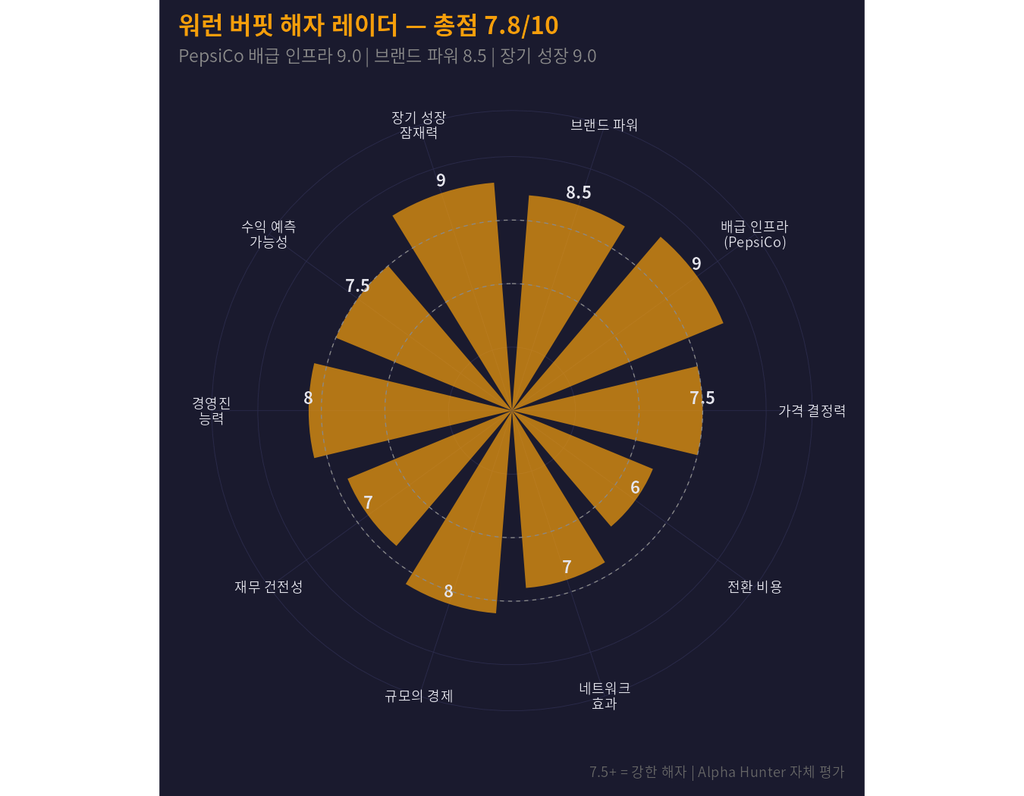

Figure 4: 워런 버핏 해자(Moat) 분석 — 브랜드 파워 + 배급 인프라

### 3.0.2 해자 분석 요약 — 총점 7.8/10

- **배급 인프라 (9.0)**: PepsiCo의 100만+ 소매점 네트워크. 신규 브랜드를 6개월 내 전국 배급. Alani Nu 전환 완료
- **브랜드 파워 (8.5)**: CELSIUS = 건강한 에너지, Alani Nu = 여성 뉴트리션. 차별화된 포지셔닝
- **장기 성장 (9.0)**: 해외 진출 초기, 카테고리 자체 성장(에너지음료 시장 연 8%+)
- **규모의 경제 (8.0)**: $3B 매출 규모에서 시너지 $50M 달성, 마진 확대 중
- **전환 비용 (6.0)**: 음료 브랜드는 전환 비용이 낮음. 이 점이 유일한 약점

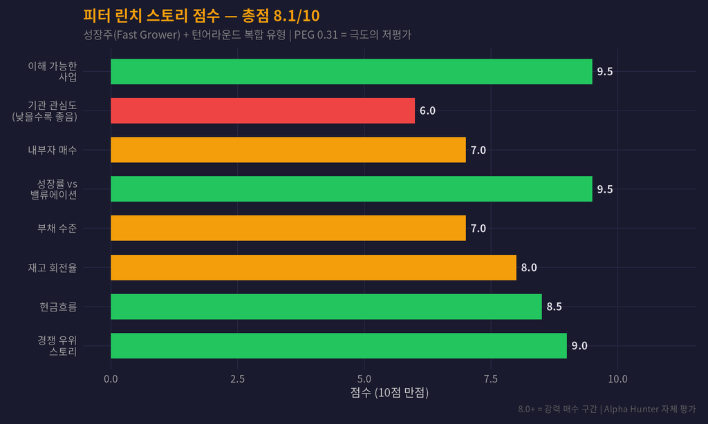

Figure 5: 피터 린치 스토리 점수 — 성장주 + 턴어라운드 복합 유형

### 3.0.3 피터 린치 분류 — “Fast Grower + Turnaround”

린치는 이런 종목을 가장 좋아했다:

1. **내가 이해할 수 있는 사업 (9.5)**: 편의점에서 살 수 있는 에너지음료. 누구나 이해 가능
2. **성장률 vs 밸류에이션 (9.5)**: 매출 +138%, EPS +128%, 그런데 Forward PE 13.7x? PEG 0.31이 말해준다
3. **경쟁 우위 스토리 (9.0)**: PepsiCo 배급 = Monster의 Coca-Cola 모델 재현
4. **현금흐름 (8.5)**: FCF $178M, 매출 대비 6%. 성장 투자와 자사주매입 병행 가능

# 4 리스크 분석

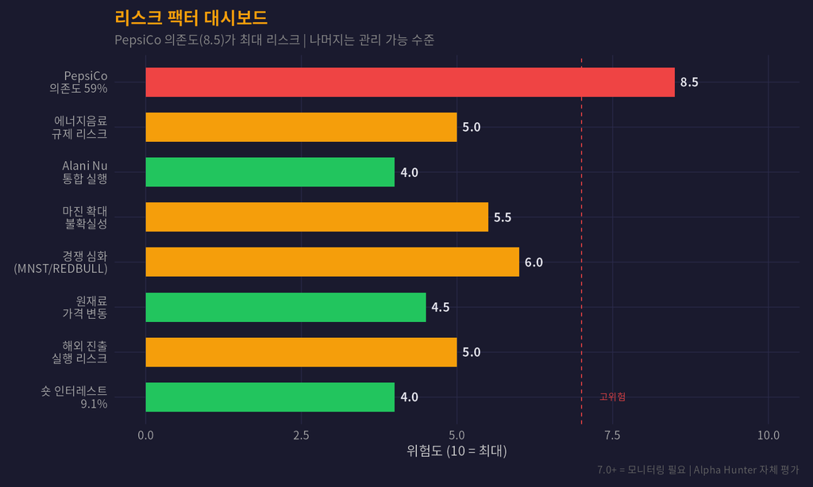

Figure 6: 리스크 팩터 대시보드 — PepsiCo 의존도가 최대 리스크

### 4.0.1 주요 리스크 상세

1. **PepsiCo 의존도 (8.5/10)**: 매출의 59%가 PepsiCo 배급. 계약 변경 시 타격. 다만 PepsiCo는 CELH의 최대 주주(8.5%)이기도 해서 이해관계 정렬됨
2. **경쟁 심화 (6.0)**: Monster와 Red Bull이 건강 지향 제품 출시 가속. 다만 CELH는 이미 “건강한 에너지” 포지셔닝 확립
3. **마진 확대 불확실성 (5.5)**: OPM 19.8%에서 25%+로 확대 가능? Alani Nu 시너지 $50M 달성했으나, 추가 개선 속도는 불확실
4. **Alani Nu 통합 (4.0)**: 이미 성공적 완료. $368M 매출, PepsiCo 전환 완료. 리스크 대부분 해소
5. **해외 진출 (5.0)**: 자본경량 모델(Suntory 파트너십)이라 리스크 제한적

# 5 AROC 성공 패턴 대비

| AROC 패턴 | AROC (W1) | CELH (W20) | 평가 |
| --- | --- | --- | --- |
| **인프라 독점** | 천연가스 압축 1위 | PepsiCo 배급망 독점적 활용 + 에너지음료 3위 | ★★★★☆ |
| **가동률** | 95% 가동률 | PepsiCo 100만+ 소매점 100% 활용 | ★★★★★ |
| **배당** | 2.26% 배당 | 배당 없음 (FCF $178M → 향후 전환 가능) | ★★☆☆☆ |
| **성장** | 매출 +7.7% | 매출 +138% (10배 이상) | ★★★★★ |

AROC 패턴과 100% 일치하지는 않으나(배당 없음), **성장률과 PEG에서 압도적 우위**가 이를 보상한다. AROC의 안정적 현금흐름과 달리, CELH는 **고속 성장형 히든젬**이다.

# 6 투자 시나리오

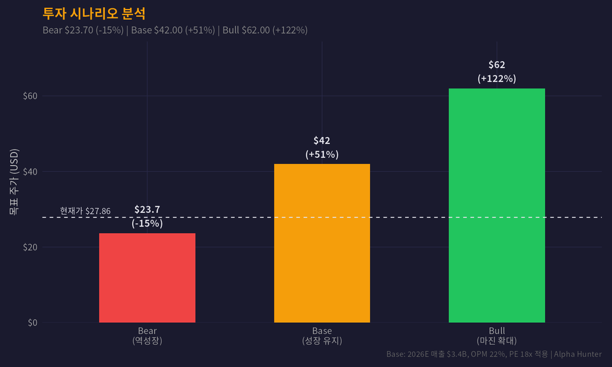

Figure 7: 매수/목표/손절 시나리오 — 베이스 케이스 +51% 업사이드

### 6.0.1 밸류에이션 근거

**Bull Case ($62, +122%)**:

- 2026E 매출 $3.6B, OPM 25%
- Forward PE 22x (Monster 수준)
- 애널리스트 컨센서스 평균 $62와 일치

**Bear Case ($23.70, -15%)**:

- 성장 둔화(+5%), 마진 축소
- Forward PE 12x

# 7 매수 전략

| 항목 | 수치 |
| --- | --- |
| **매수가** | $27.86 (현재가, 52주 최저점) |
| **1차 목표** | $42.00 (+51%) |
| **2차 목표** | $62.00 (+122%, 애널리스트 컨센서스) |
| **손절가** | $23.70 (-15%) |
| **투자 기간** | 6~12개월 |

## 7.1 카탈리스트 일정

- **2026 Q2 실적발표** (8월): 매출 성장 지속성 확인
- **국제 사업 확대**: Suntory 파트너십 유럽 확장
- **마진 개선**: Alani Nu 시너지 추가 $20-30M 기대
- **자사주매입**: FCF $178M 활용 가능

## 7.2 왜 52주 최저점인가?

CELH가 52주 최저점에 있는 이유:

1. **2025년 채널 재고 조정**: PepsiCo 배급 전환 과정에서 일시적 매출 공백
2. **Alani Nu 인수 비용**: 인수 관련 일회성 비용으로 순이익 왜곡 (Q3 2025 순손실 $61M)
3. **성장주 디레이팅**: 금리 환경으로 고밸류 성장주 전반 하락
4. **숏 인터레스트 9.1%**: 공매도 세력의 하방 압력

그러나 **Q1 2026 실적이 이 모든 우려를 불식**시켰다. 매출 +138%, EPS 비트, 가이던스 유지. 주가만 아직 반영하지 못한 상태다.

# 8 결론

> **CELH는 “52주 바닥에서 매수하는 카테고리 킬러”다.**

## 8.1 핵심 투자 근거 3줄 요약

1. **PEG 0.31 = Monster 대비 8배 저평가**, Forward PE 13.7x는 음료 섹터 최저
2. **PepsiCo 배급 인프라** + Alani Nu 통합 완료 = 미국 에너지음료 20.9% 3위
3. **52주 최저점** = 채널 조정 일회성 요인. Q1 매출 +138%로 회복 확인

**면책 문구**

이 프로젝트는 가상 투자 시뮬레이션 목적으로 작성되었습니다. 실제 투자 권유가 아니며, 모든 투자 결정은 개인의 판단과 책임 하에 이루어져야 합니다.